# 03: Cluster analysis: DBSCAN

**Author:** Grace Akatsu

**Class:** CPBS 7602, Fall 2025

## Overview

This notebook performs cluster analysis on the GTEx data from notebook 01, using DBSCAN (Density-Based Spatial Clustering of Applications with Noise) clustering.

- Import libraries
- Set paths and seed
- Read in data
- Parameter tuning: consensus
- Parameter tuning: elbow method
  - Initial parameter exploration
  - Adjusted parameter range
  - Cluster analysis by eps value
  - Final parameter tuning
- Visualize with PCA
- Save model outputs for DBSCAN

## Import libraries

```python
import os
import numpy as np
import pandas as pd
from sklearn.cluster import DBSCAN
from sklearn.metrics import adjusted_rand_score as ari
import itertools
import matplotlib.pyplot as plt
from sklearn.metrics import silhouette_score
from collections import Counter
```

## Set paths and seed

```python
DATA_FILE = "clean_data/gtex_top10_tissues_top5000_variable_genes_standardized.csv"
DBSCAN_OUTPUTS = "DBSCAN_outputs"

os.makedirs(DBSCAN_OUTPUTS, exist_ok=True)
```

```python
np.random.seed(0)
```

## Read in data

```python
data = pd.read_csv(
    DATA_FILE,
    index_col="SAMPID"
)

data.head()
```

| SAMPID | Tissue | ENSG00000244734.3 | ENSG00000188536.12 | ENSG00000198804.2 | ENSG00000198938.2 | ENSG00000163220.10 | ENSG00000198899.2 | ENSG00000198886.2 | ENSG00000198712.1 | ENSG00000143632.14 | ... | ENSG00000261236.7 | ENSG00000188112.8 | ENSG00000170035.15 | ENSG00000024862.17 | ENSG00000213619.9 | ENSG00000176087.14 | ENSG00000115596.3 | ENSG00000138386.16 | ENSG00000182872.15 | ENSG00000070669.16 |
| --- | --- | --- | --- | --- | --- | --- | --- | --- | --- | --- | --- | --- | --- | --- | --- | --- | --- | --- | --- | --- | --- |
| GTEX-1117F-0226-SM-5GZZ7 | Adipose - Subcutaneous | -0.317682 | -0.320624 | -0.822484 | -0.623593 | -0.278153 | -0.845429 | -0.920044 | -0.944370 | -0.332153 | ... | -0.259958 | 0.087855 | 0.714803 | 0.769940 | 0.143898 | -0.476630 | -0.245165 | -0.547999 | -0.027921 | -0.037272 |
| GTEX-1117F-0426-SM-5EGHI | Muscle - Skeletal | -0.319849 | -0.322180 | 0.219063 | 1.660759 | -0.278587 | 1.286640 | 0.307966 | 0.663645 | 1.117576 | ... | 1.470513 | -0.589025 | -0.033767 | -0.572090 | 0.467826 | -0.715005 | -0.381079 | -1.292842 | -0.339644 | -1.050707 |
| GTEX-1117F-0526-SM-5EGHJ | Artery - Tibial | -0.319430 | -0.321842 | -0.872736 | -0.647149 | -0.278998 | -0.710659 | -0.839425 | -0.911312 | -0.332987 | ... | -0.509545 | -0.527738 | -0.000939 | -0.229877 | -0.396138 | -1.214898 | -0.315997 | -0.447965 | 1.078165 | 0.048887 |
| GTEX-1117F-2926-SM-5GZYI | Skin - Not Sun Exposed (Suprapubic) | -0.320043 | -0.321507 | -0.525812 | -0.609139 | -0.276681 | -0.633970 | -0.646396 | -0.870145 | -0.332046 | ... | -0.344541 | 0.708257 | -0.008799 | 0.094763 | -0.049997 | -0.492368 | -0.070677 | 1.017824 | 0.276392 | 0.139678 |
| GTEX-111CU-0226-SM-5GZXC | Thyroid | -0.321842 | -0.323617 | -0.064829 | 0.022578 | -0.267405 | 0.605461 | 0.046808 | 0.438473 | -0.332147 | ... | 0.941758 | 0.128075 | 0.421663 | 0.986367 | 0.335941 | 1.521090 | -0.368260 | -0.127483 | 0.448233 | 5.554269 |

5 rows × 5001 columns

```python
# Set input
X = data.drop(columns=["Tissue"])
# Set target
y = data["Tissue"]
```

## Parameter tuning: consensus index method

Let's use the consensus index method to determine the best value for "eps" (the maximum distance between neighbor samples and core samples for those neighbor samples to be considered part of the cluster).

```python
n_reps = 20
eps_vals = np.linspace(0.10, 0.90, 20)

stability_scores = []
all_labels = []

for eps in eps_vals:
    labels_list = []

    # repeat DBSCAN
    for _ in range(n_reps):
        model = DBSCAN(eps=eps).fit(X)
        labels_list.append(model.labels_)

    all_labels.append(labels_list)

    # compute pairwise ARI
    ari_values = []
    for lbl1, lbl2 in itertools.combinations(labels_list, 2):
        ari_values.append(ari(lbl1, lbl2))

    # mean ARI for this eps = stability score
    stability_scores.append(np.mean(ari_values))
```

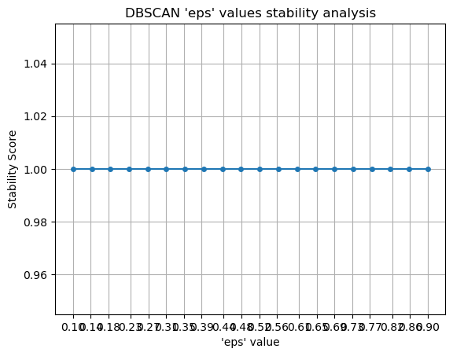

```python
# Visualize stability scores
plt.plot(eps_vals, stability_scores, marker=".", linestyle="-", markersize=8)
plt.xlabel("'eps' value")
plt.ylabel("Stability Score")
plt.grid(True)
plt.xticks(np.round(eps_vals, 2))
plt.title("DBSCAN 'eps' values stability analysis")
plt.show()
```

After completing this analysis and seeing the results, I realize that the stability score is the wrong way to assess this parameter. DBSCAN is a deterministic model, so the same X and eps value will produce the same output every time. I will move on to the elbow method.

## Parameter tuning: elbow method

### Initial parameter exploration

```python
# Use elbow method to visualize silhouette score values for different eps values

eps_vals = np.linspace(0.10, 0.90, 10)
sil_scores = []

for eps in eps_vals:
    model = DBSCAN(eps=eps).fit(X)

    labels = model.labels_
    # Silhouette cannot be computed with 0 or 1 clusters
    if len(set(labels)) <= 1 or (len(set(labels)) == 2 and -1 in set(labels)):
        sil_scores.append(np.nan)
    else:
        sil_scores.append(silhouette_score(X, labels))
```

```python
sil_scores
```

```
[nan, nan, nan, nan, nan, nan, nan, nan, nan, nan]
```

These are all undefined, meaing that there are not enough clusters and my eps values are too small. Let's try again with larger values.

### Adjusted parameter range

```python
# Use elbow method to visualize silhouette score values for different eps values

eps_vals = np.linspace(1, 20, 10)
sil_scores = []

for eps in eps_vals:
    model = DBSCAN(eps=eps).fit(X)

    labels = model.labels_
    # Silhouette cannot be computed with 0 or 1 clusters
    if len(set(labels)) <= 1 or (len(set(labels)) == 2 and -1 in set(labels)):
        sil_scores.append(np.nan)
    else:
        sil_scores.append(silhouette_score(X, labels))
```

```python
sil_scores
```

```
[nan,
 nan,
 nan,
 nan,
 nan,
 np.float64(-0.0244083377735816),
 nan,
 np.float64(-0.042384116491393314),
 np.float64(-0.04869096718468081),
 np.float64(0.0025629421494460926)]
```

Getting there, but still too many undefined values. Let's increase more.

```python
# Use elbow method to visualize silhouette score values for different eps values

eps_vals = np.linspace(10, 60, 30)
sil_scores = []

for eps in eps_vals:
    model = DBSCAN(eps=eps).fit(X)

    labels = model.labels_
    # Silhouette cannot be computed with 0 or 1 clusters
    if len(set(labels)) <= 1 or (len(set(labels)) == 2 and -1 in set(labels)):
        sil_scores.append(np.nan)
    else:
        sil_scores.append(silhouette_score(X, labels))
```

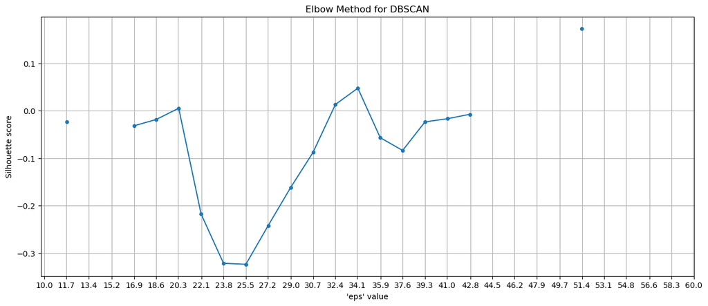

```python
# Visualize
plt.figure(figsize=(15, 6))
plt.plot(eps_vals, sil_scores, ".-", markersize=8)
plt.xlabel("'eps' value")
plt.ylabel("Silhouette score")
plt.title("Elbow Method for DBSCAN")
plt.grid(True)
plt.xticks(np.round(eps_vals, 1))
plt.show()
```

I do not see a clear "elbow." What's more, the silhouette score ranges from 1 to -1, with 1 being the best score, and none of these eps values seem to be yielding a particularly high score.

Let's look at how many clusters are being identified, and what fraction of samples are being assigned to clusters (rather than being unassigned aka designated as noise), for each eps value.

### Cluster analysis by eps value

```python
eps_vals = np.linspace(10, 60, 30)

num_clusters = []
cluster_fraction = []

for eps in eps_vals:
    model = DBSCAN(eps=eps).fit(X)
    labels = model.labels_

    counts = Counter(labels)

    # Identify real clusters (exclude noise label -1)
    cluster_labels = [lab for lab in counts.keys() if lab != -1]

    # Number of clusters
    num_clusters.append(len(cluster_labels))

    # Fraction of points assigned to a cluster (not noise)
    n_clustered = sum(counts[lab] for lab in cluster_labels)
    frac = n_clustered / len(labels)
    cluster_fraction.append(frac)

    print(f"eps={eps:.2f} | clusters={len(cluster_labels)} | clustered fraction={frac:.3f}")
```

[output not shown]

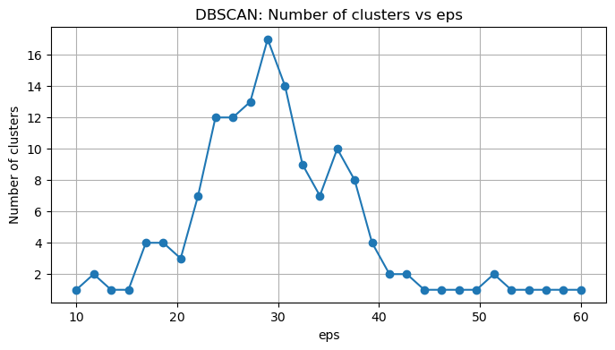

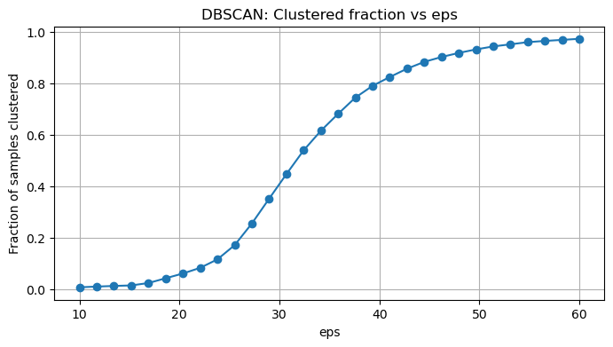

```python
# Visualize number of clusters vs eps
plt.figure(figsize=(8,4))
plt.plot(eps_vals, num_clusters, marker='o')
plt.xlabel("eps")
plt.ylabel("Number of clusters")
plt.title("DBSCAN: Number of clusters vs eps")
plt.grid(True)
plt.show()

# Visualize fraction of samples clustered vs eps
plt.figure(figsize=(8,4))
plt.plot(eps_vals, cluster_fraction, marker='o')
plt.xlabel("eps")
plt.ylabel("Fraction of samples clustered")
plt.title("DBSCAN: Clustered fraction vs eps")
plt.grid(True)
plt.show()
```

This clarifies some things. It seems that the data's density distribution is such that creating specific clusters is difficult without discarding many samples.

Let's try one more iteration of eps value parameter tuning, this time using values between 20 and 40.

### Final parameter tuning

```python
# Use elbow method to visualize silhouette score values for different eps values

eps_vals = np.linspace(20, 40, 20)
sil_scores = []

for eps in eps_vals:
    model = DBSCAN(eps=eps).fit(X)

    labels = model.labels_
    # Silhouette cannot be computed with 0 or 1 clusters
    if len(set(labels)) <= 1 or (len(set(labels)) == 2 and -1 in set(labels)):
        sil_scores.append(np.nan)
    else:
        sil_scores.append(silhouette_score(X, labels))
```

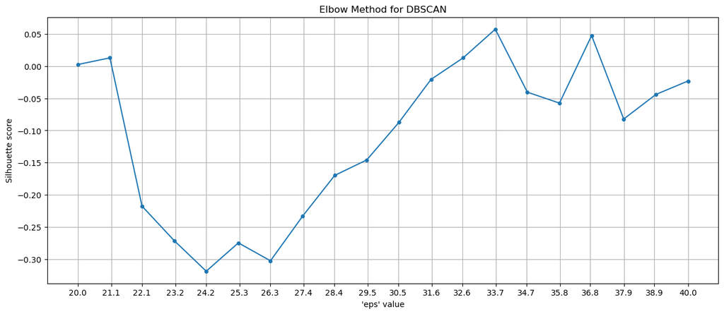

```python
# Visualize
plt.figure(figsize=(15, 6))
plt.plot(eps_vals, sil_scores, ".-", markersize=8)
plt.xlabel("'eps' value")
plt.ylabel("Silhouette score")
plt.title("Elbow Method for DBSCAN")
plt.grid(True)
plt.xticks(np.round(eps_vals, 1))
plt.show()
```

```python
eps_vals = np.linspace(20, 40, 20)

num_clusters = []
cluster_fraction = []

for eps in eps_vals:
    model = DBSCAN(eps=eps).fit(X)
    labels = model.labels_

    counts = Counter(labels)

    # Identify real clusters (exclude noise label -1)
    cluster_labels = [lab for lab in counts.keys() if lab != -1]

    # Number of clusters
    num_clusters.append(len(cluster_labels))

    # Fraction of points assigned to a cluster (not noise)
    n_clustered = sum(counts[lab] for lab in cluster_labels)
    frac = n_clustered / len(labels)
    cluster_fraction.append(frac)

    print(f"eps={eps:.2f} | clusters={len(cluster_labels)} | clustered fraction={frac:.3f}")
```

[output not shown]

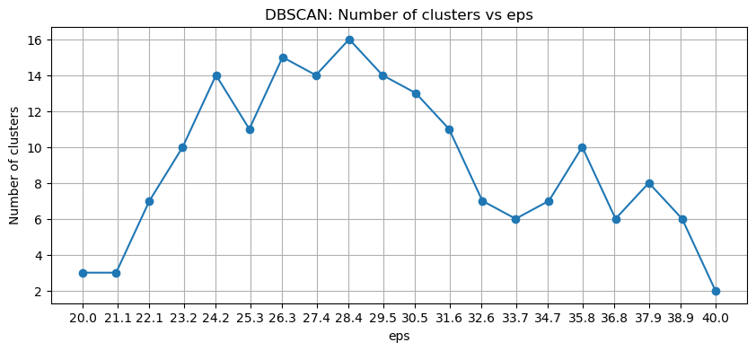

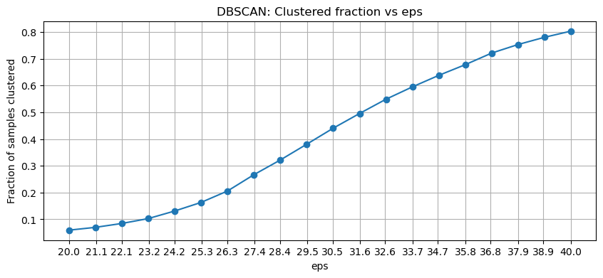

```python
# Visualize number of clusters vs eps
plt.figure(figsize=(10,4))
plt.plot(eps_vals, num_clusters, marker='o')
plt.xlabel("eps")
plt.ylabel("Number of clusters")
plt.xticks(np.round(eps_vals, 1))
plt.title("DBSCAN: Number of clusters vs eps")
plt.grid(True)
plt.show()

# Visualize fraction of samples clustered vs eps
plt.figure(figsize=(10,4))
plt.plot(eps_vals, cluster_fraction, marker='o')
plt.xlabel("eps")
plt.ylabel("Fraction of samples clustered")
plt.xticks(np.round(eps_vals, 1))
plt.title("DBSCAN: Clustered fraction vs eps")
plt.grid(True)
plt.show()
```

There is no visible "elbow," so I will have to assess the tradeoff between number of clusters and fraction of samples clustered. Subjectively, I will choose an eps value of 35.8, which has 10 clusters and a little less than 70% sample assignment to a cluster.

## Visualize with PCA

Visualize the DBSCAN clustering results with eps=35.8 using PCA to compare cluster assignments with true tissue types.

```python
# Import additional libraries needed for visualization
from sklearn.decomposition import PCA
from matplotlib.patches import Patch

# Train DBSCAN model with eps=35.8
dbscan_model = DBSCAN(eps=35.8).fit(X)
dbscan_labels = dbscan_model.labels_

print(f"Number of clusters: {len(set(dbscan_labels)) - (1 if -1 in dbscan_labels else 0)}")
print(f"Number of noise points: {list(dbscan_labels).count(-1)}")
print(f"Fraction of samples clustered: {(len(dbscan_labels) - list(dbscan_labels).count(-1)) / len(dbscan_labels):.3f}")
```

```
Number of clusters: 10
Number of noise points: 2080
Fraction of samples clustered: 0.679
```

```python
# Perform PCA for visualization
pca = PCA(n_components=2)
data_pca = pca.fit_transform(X)

# Map tissue types to numerical values for coloring
tissues = data["Tissue"].unique().tolist()
tissue_to_num = {t: i for i, t in enumerate(tissues)}
tissue_numbers = data["Tissue"].map(tissue_to_num).tolist()

# Use a colormap with enough distinct colors
cmap = plt.cm.get_cmap("tab20", len(tissues))

# Create legend handles for tissue types
legend_handles = [
    Patch(facecolor=cmap(i), label=tissues[i])
    for i in range(len(tissues))
]
```

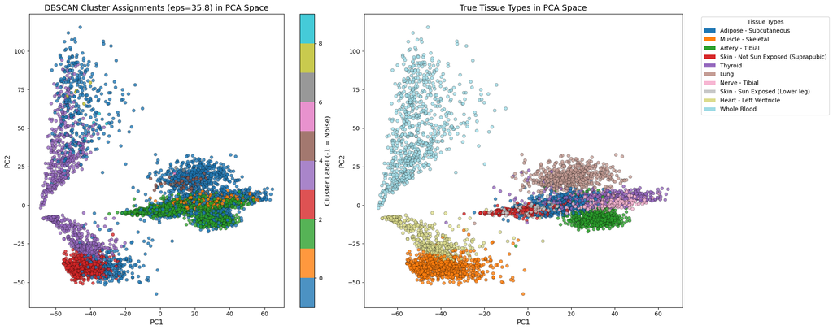

```python
# Compare DBSCAN cluster assignments and tissue types in PCA space
# Create subplots
fig, (ax1, ax2) = plt.subplots(1, 2, figsize=(20, 8))

# Plot 1: Colored by DBSCAN cluster assignments
# Handle noise points (label -1) separately
scatter1 = ax1.scatter(
    data_pca[:, 0], data_pca[:, 1],
    c=dbscan_labels, cmap="tab10",
    s=30, alpha=0.8, edgecolors='black', linewidth=0.3
)
ax1.set_title("DBSCAN Cluster Assignments (eps=35.8) in PCA Space", fontsize=14)
ax1.set_xlabel("PC1", fontsize=12)
ax1.set_ylabel("PC2", fontsize=12)
cbar1 = plt.colorbar(scatter1, ax=ax1)
cbar1.set_label("Cluster Label (-1 = Noise)", fontsize=12)

# Plot 2: Colored by tissue types
scatter2 = ax2.scatter(
    data_pca[:, 0], data_pca[:, 1],
    c=tissue_numbers, cmap=cmap,
    s=30, alpha=0.8, edgecolors='black', linewidth=0.3
)
ax2.set_title("True Tissue Types in PCA Space", fontsize=14)
ax2.set_xlabel("PC1", fontsize=12)
ax2.set_ylabel("PC2", fontsize=12)

# Add tissue type legend to the second plot
ax2.legend(handles=legend_handles, bbox_to_anchor=(1.05, 1), loc="upper left", title="Tissue Types")

plt.tight_layout()

# Save the plot
plt.savefig(os.path.join(DBSCAN_OUTPUTS, "DBSCAN_cluster_assignments_PCA.png"))

plt.show()
```

The clusters don't look amazing, but we will save the outputs anyway for comparison.

## Save model outputs for DBSCAN

```python
# Create a dataframe of DBSCAN cluster assignments to save
dbscan_assignments_df = pd.DataFrame({'dbscan_cluster_assignments': dbscan_labels},
                                  index=X.index)

dbscan_assignments_df.head()
```

| SAMPID | dbscan_cluster_assignments |
| --- | --- |
| GTEX-1117F-0226-SM-5GZZ7 | -1 |
| GTEX-1117F-0426-SM-5EGHI | -1 |
| GTEX-1117F-0526-SM-5EGHJ | -1 |
| GTEX-1117F-2926-SM-5GZYI | -1 |
| GTEX-111CU-0226-SM-5GZXC | 0 |

```python
#Save DBSCAN cluster assignments to CSV
dbscan_assignments_df.to_csv(os.path.join(DBSCAN_OUTPUTS, "dbscan_cluster_assignments.csv"))
```